# An Simple Analysis of Dataset ‘mtcars’

##### This R Markdown document has been created to explore the dataset [mtcars](https://stat.ethz.ch/R-manual/R-devel/library/datasets/html/00Index.html) located in the R Datasets Package for [Assignment 1](https://stat545.stat.ubc.ca/evaluation/hw01/hw01/)

#### **Description of dataset ‘mtcars’**

##### The datatset **‘mtcars’** is a dataset that contains 11 numeric variables with a total of 32 observations. Full description of the dataset can be found [here](https://stat.ethz.ch/R-manual/R-devel/library/datasets/html/mtcars.html).

#### **The variables are:-**

> | Variable | Description |
> | --- | --- |
> | mpg | Miles/(US) gallon |
> | cyl | Number of cylinders |
> | disp | Displacement (cu.in.) |
> | hp | Gross horsepower |
> | drat | Rear axle ratio |
> | wt | Weight (1000 lbs) |
> | qsec | 1/4 mile time |
> | vs | Engine (0 = V-shaped, 1 = straight) |
> | am | Transmission (0 = automatic, 1 = manual) |
> | gear | Number of forward gears |
> | carb | Number of carburetors |

#### **Dataset Structure**

##### The **structure** of the dataset can be seen below-

```
## 'data.frame':    32 obs. of  11 variables:
##  $ mpg : num  21 21 22.8 21.4 18.7 18.1 14.3 24.4 22.8 19.2 ...
##  $ cyl : num  6 6 4 6 8 6 8 4 4 6 ...
##  $ disp: num  160 160 108 258 360 ...
##  $ hp  : num  110 110 93 110 175 105 245 62 95 123 ...
##  $ drat: num  3.9 3.9 3.85 3.08 3.15 2.76 3.21 3.69 3.92 3.92 ...
##  $ wt  : num  2.62 2.88 2.32 3.21 3.44 ...
##  $ qsec: num  16.5 17 18.6 19.4 17 ...
##  $ vs  : num  0 0 1 1 0 1 0 1 1 1 ...
##  $ am  : num  1 1 1 0 0 0 0 0 0 0 ...
##  $ gear: num  4 4 4 3 3 3 3 4 4 4 ...
##  $ carb: num  4 4 1 1 2 1 4 2 2 4 ...
```

##### The variables **vs** (engine) and **am** (Transmission) are factor variables with two levels (0 and 1).

#### **Checking for missing values**

##### The **‘anyNA’** function is used to check if the dataset contains any missing values. As the ouput of the function is **FALSE**, it indicates all non-missing values in the dataset.

```
## [1] FALSE
```

#### **Checking for Skewness**

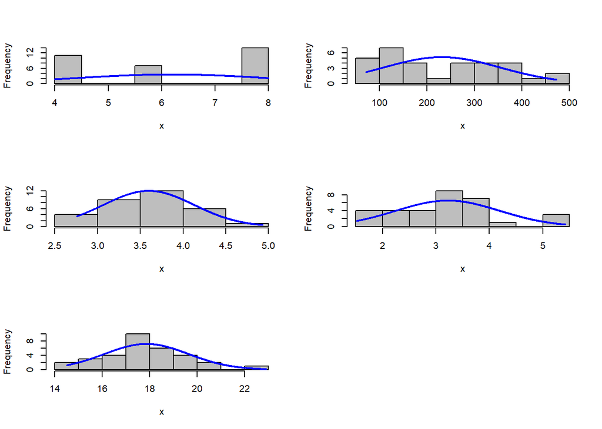

##### The varibales **hp, mpg, gear** and **carb** are **right skewed**. (Graphs in order of the variables listed).

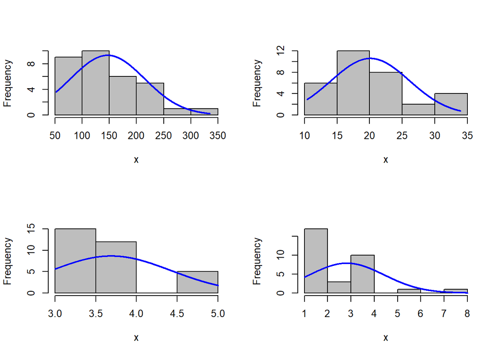

#### **Scatterplots (to identify relationship between variables)**

##### Below are the sample scatterplots of variables **wt vs mpg** and **wt vs disp**. The variables **wt** and **mpg** is negatively related as the points in the graph show a downhill pattern as we move from left to right while the variables **wt** and **disp** are positively related to each other as the data points for x increase as y values increase.

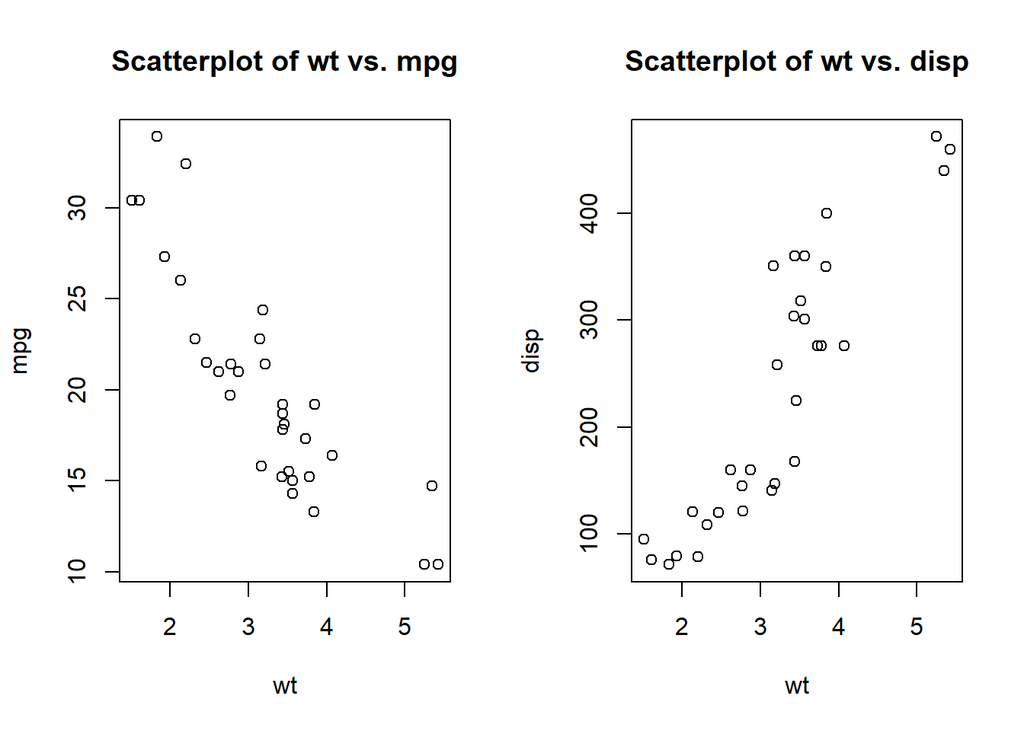

#### **Linear Regression**

##### We use a simple linear regression function to predict miles/gallon (**mpg** - response variable) travelled from weight (**wt** - predictor variable) of the car (shown below). The analysis is provided in the listing below and the resulting graph is presented.

```
##
## Call:
## lm(formula = mpg ~ wt, data = mtcars)
##
## Residuals:
##     Min      1Q  Median      3Q     Max
## -4.5432 -2.3647 -0.1252  1.4096  6.8727
##
## Coefficients:
##             Estimate Std. Error t value Pr(>|t|)
## (Intercept)  37.2851     1.8776  19.858  < 2e-16 ***
## wt           -5.3445     0.5591  -9.559 1.29e-10 ***
## ---
## Signif. codes:  0 '***' 0.001 '**' 0.01 '*' 0.05 '.' 0.1 ' ' 1
##
## Residual standard error: 3.046 on 30 degrees of freedom
## Multiple R-squared:  0.7528, Adjusted R-squared:  0.7446
## F-statistic: 91.38 on 1 and 30 DF,  p-value: 1.294e-10
```

##### We can see from the output that the model fits our data moderately well as indicated by the **Multiple R-squared value** of **0.75**. This indicates that the model accounts for **75%** of the variance in mpg (miles/gallon).

##### We can also see that the **regression coefficient (-5.3)** is significantly different from zero (p < 0.001) and indicates that there’s an expected decrease of 5.3 units of mpg for every 1 unit increase in wt.

#### **Regression plot**

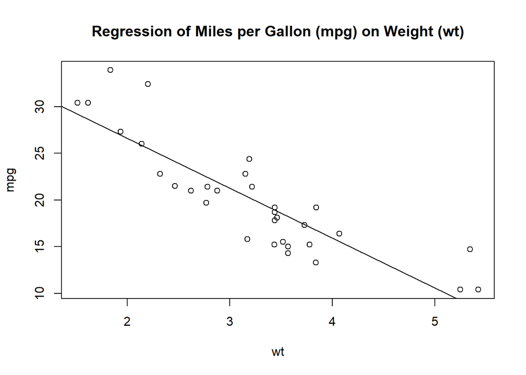

##### The plot shows the regression line fitted by the model. As the data values lie around this line, this indicates that the model fits the data well.